# R俱乐部

## day06

### 杜 月新

### RStudio

### 2020/11/30

## Day06  :回归分析

-　参考：鹿野　繁樹「新しい計量経済学」

# 回归分析

- 考虑两个变量Y与X的关系，希望用X值的变化解释Y值的变化。

- X⇒自变量  independent variable
 - Y⇒因变量  response variable

- X如果只有一个时称为一元回归，2个以上时称为多元线回归

- 准备：程序包dataets   ⇒women（使用这个数据作为例子）

```r
women
```

```
##    height weight
## 1      58    115
## 2      59    117
## 3      60    120
## 4      61    123
## 5      62    126
## 6      63    129
## 7      64    132
## 8      65    135
## 9      66    139
## 10     67    142
## 11     68    146
## 12     69    150
## 13     70    154
## 14     71    159
## 15     72    164
```

#一元回归的实践1

> 在实行一元回归之前，一定要线画散布图让数据直观化。

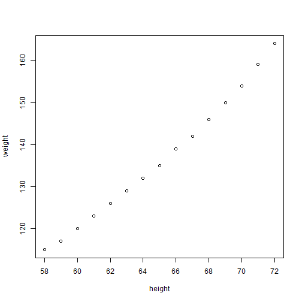

```r
plot(women)
```

# 一元回归的实践2

> 从散布图上来看，这俩个变数之间有关系。↓
 - 试一下回归

```r
m=lm(weight~height,data=women)
m
```

```
##
## Call:
## lm(formula = weight ~ height, data = women)
##
## Coefficients:
## (Intercept)       height
##      -87.52         3.45
```

结果显示：
weight=−87.52+3.45 height+(error)

# 一元回归的实践3

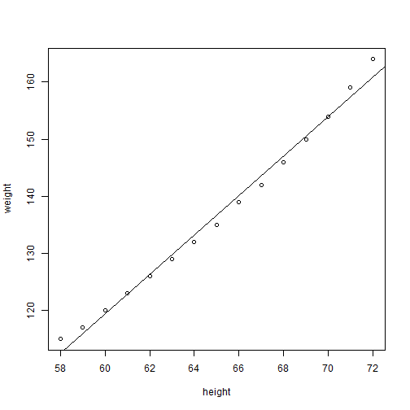

```r
plot(women)
abline(m)
```

# 一元回归的实践4--预测prediction

- 使用刚才的结果显示的式子，我们可以做预测。
`$$\hat{weight}=-87.52+3.45height$$`
问题：身高60.8英尺的人体重为多少呢？

```r
new = data.frame(height = 60.8)
new$weight = predict(m, new)
new
```

```
##   height   weight
## 1   60.8 122.2433
```

# 最小二乘法

直观上，要找最优的直线y=a+bx使得直线与观测到的点最接近。例如下图：

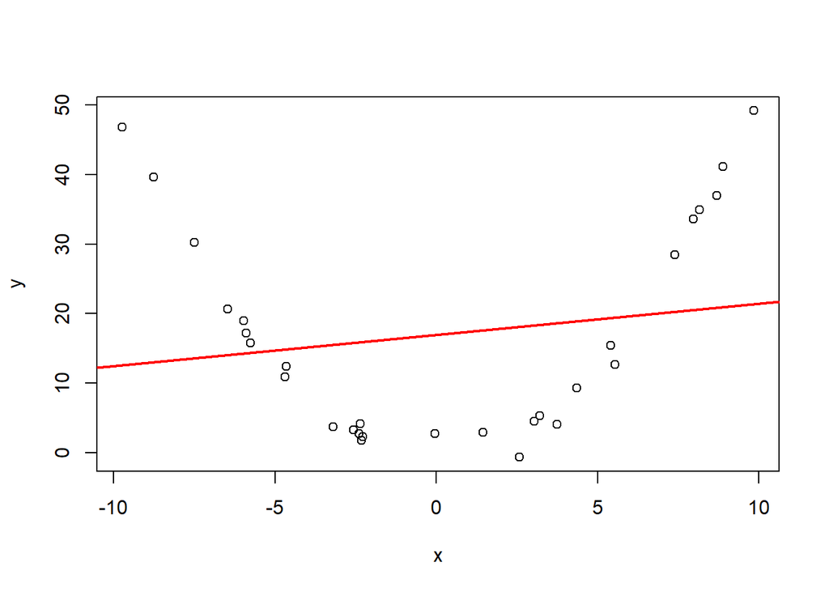

>在这里，a,b的解要用最小二乘法得到；
 - 详细参照：鹿野　繁樹「新しい計量経済学」Chapter4

`$$min\sum(y_{i}-a-bx_{i})^{2}$$`
最小二乘解表达式为
`$$\hat{b}=\frac{\sum_{i}(x_{i}-\bar{x})(y_{i}-\bar{y})}{\sum_{i}(x_{i}-\bar{x})^{2}}$$`
`$$\hat{a}=\bar{y}-\hat{b}\bar{x}$$`

估计结果：

- 拟合值（预测值）

`$$\hat{y_{i}}=\hat{a}+\hat{b}x_{i}$$` i=1,2,3,...n

- 残差
`$$e_{i}=y_{i}-\hat{y_{i}}$$`  i=1,2,3,...n

- `$$SSE=\sum_{i}e_{i}^{2}$$`
称为残差平方和，残差平方和小则拟合优。

# 判定系数R-square

- y是因变量， 因变量的数据的离差平方和

`$$SST=\sum_{i}(y_{i}-\bar{y})^{2}$$`
代表了因变量的未知变动大小， 需要对这样的变动用自变量进行解释， 称SST为总平方和。
- 回归平方和
`$$SSR=\sum_{i}(\hat{y_{i}}-\bar{y})^{2}=\hat{b^{2}\sum_{i}(\hat{x}_{i}-\bar{x})^{2}}$$`

- SST=SSR+SSE
分解中，回归平方和越大，误差平方和越小， 拟合越好。 令
`$$R^{2}=\frac{SSR}{SST}=1-\frac{SSE}{SST}$$`
称为回归的复相关系数，或判定系数。
`$$0\leq R^{2}\leq1$$`
判定系数越大，回归拟合越好。

# 线性关系显著性检验

当b=0时，模型退化为Y=a+error，X不出现在模型中，说明Y与X不相关。
- 检验
`$$H_{0}:b=0\mid H_{1}:b\neq0$$`

- 如果想要知道统计的具体结果，可以用summary（）。

- R的回归结果中显示为“residual standard error”（残差标准误差）。

```r
summary(m)
```

```
##
## Call:
## lm(formula = weight ~ height, data = women)
##
## Residuals:
##     Min      1Q  Median      3Q     Max
## -1.7333 -1.1333 -0.3833  0.7417  3.1167
##
## Coefficients:
##              Estimate Std. Error t value Pr(>|t|)
## (Intercept) -87.51667    5.93694  -14.74 1.71e-09
## height        3.45000    0.09114   37.85 1.09e-14
##
## (Intercept) ***
## height      ***
## ---
## Signif. codes:
## 0 '***' 0.001 '**' 0.01 '*' 0.05 '.' 0.1 ' ' 1
##
## Residual standard error: 1.525 on 13 degrees of freedom
## Multiple R-squared:  0.991,	Adjusted R-squared:  0.9903
## F-statistic:  1433 on 1 and 13 DF,  p-value: 1.091e-14
```

Coefficients:
              Estimate Std. Error t value Pr(>|t|)

(Intercept) -87.51667    5.93694  -14.74 1.71e-09 ***

height        3.45000    0.09114   37.85 1.09e-14 ***
- 从这里可以看出，p值小于1%，所以b=0的虚无假说可以舍弃。

# 回归系数的信赖区间

- 信赖区间可以通过confint来求。

```r
confint(m)
```

```
##                   2.5 %     97.5 %
## (Intercept) -100.342655 -74.690679
## height         3.253112   3.646888
```

# 多元回归的实践1

- 准备：下载数据Wooldridge
 - install.packages("wooldridge")

```r
library(wooldridge)
data("wage1")
```

# wooldridge::wage1 数据

- 我们先看一下wage1数据包含的内容

```r
?wage1
```

- nrow=526,ncol=24

# 抽出数据

- 这次选用以下几个变量的数据

```r
wage=wage1[c('lwage','educ','exper','tenure')]
head(wage)
```

```
##      lwage educ exper tenure
## 1 1.131402   11     2      0
## 2 1.175573   12    22      2
## 3 1.098612   11     2      0
## 4 1.791759    8    44     28
## 5 1.667707   12     7      2
## 6 2.169054   16     9      8
```

# data的直观化

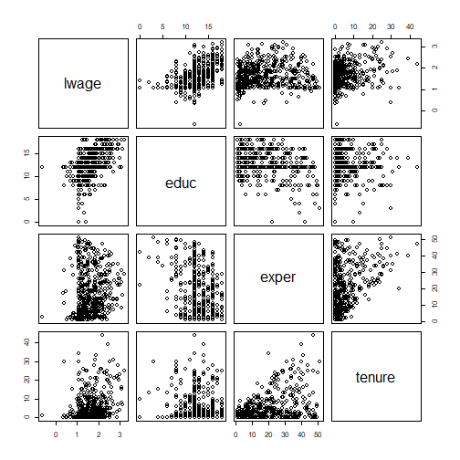

```r
plot(wage)
```

# 变量的统计量介绍

- install.packages("sjPlot")

```r
sjmisc::descr(wage)
```

```
##
## ## Basic descriptive statistics
##
##     var    type  label   n NA.prc  mean    sd   se
##   lwage numeric  lwage 526      0  1.62  0.53 0.02
##    educ integer   educ 526      0 12.56  2.77 0.12
##   exper integer  exper 526      0 17.02 13.57 0.59
##  tenure integer tenure 526      0  5.10  7.22 0.32
##     md trimmed             range        iqr  skew
##   1.54    1.59 3.85 (-0.63-3.22)  0.7256464  0.39
##  12.00   12.69         18 (0-18)  2.0000000 -0.62
##  13.50   15.64         50 (1-51) 21.0000000  0.71
##   2.00    3.49         44 (0-44)  7.0000000  2.12
```

# 多元回归分析

```r
model=lm(lwage~educ+exper+tenure,data=wage)
summary(model)
```

```
##
## Call:
## lm(formula = lwage ~ educ + exper + tenure, data = wage)
##
## Residuals:
##      Min       1Q   Median       3Q      Max
## -2.05802 -0.29645 -0.03265  0.28788  1.42809
##
## Coefficients:
##             Estimate Std. Error t value Pr(>|t|)
## (Intercept) 0.284360   0.104190   2.729  0.00656 **
## educ        0.092029   0.007330  12.555  < 2e-16 ***
## exper       0.004121   0.001723   2.391  0.01714 *
## tenure      0.022067   0.003094   7.133 3.29e-12 ***
## ---
## Signif. codes:
## 0 '***' 0.001 '**' 0.01 '*' 0.05 '.' 0.1 ' ' 1
##
## Residual standard error: 0.4409 on 522 degrees of freedom
## Multiple R-squared:  0.316,	Adjusted R-squared:  0.3121
## F-statistic: 80.39 on 3 and 522 DF,  p-value: < 2.2e-16
```

# 保存结果

- 直接copy
- 参考 sjPlot::tab_model

```r
sjPlot::tab_model(model, show.se = TRUE, show.stat = TRUE,collapse.se = TRUE, file = 'test.doc')
```

|  | lwage |  |  |  |
| --- | --- | --- | --- | --- |
| Predictors | Estimates | CI | Statistic | p |
| (Intercept) | 0.28 (0.10) | 0.08 – 0.49 | 2.73 | **0.007** |
| educ | 0.09 (0.01) | 0.08 – 0.11 | 12.56 | **<0.001** |
| exper | 0.00 (0.00) | 0.00 – 0.01 | 2.39 | **0.017** |
| tenure | 0.02 (0.00) | 0.02 – 0.03 | 7.13 | **<0.001** |
| Observations | 526 |  |  |  |
| R<sup>2</sup> / R<sup>2</sup> adjusted | 0.316 / 0.312 |  |  |  |

# 加权线性回归（Weighted Linear Regression）

- 误差项的分散有好几种
 >Y = 消費と X = 所得 とすれば，X が増えるに連れて，Y の分散は大きくなる。 所得が多いほど消費と貯蓄の選択に自由度が増えるから。

>Y = ある都道府県の1人あたり年間パン消費量, X = その都道府県の平均所得額。 平均値は標本数が増えると分散が減少するという性質があるので，標本が少ない 都道府県ほど分散が大きい。

- →加权使分散均衡，提高估计精度。

# 加权线回归的实践

- 鹿野 (2015, §11.4) の例: 全国消費実態調査
 - 这里的数据取了各个group的平均值，各group的观测数量为ni ，分散为σ2/ni。   wi=ni

```r
df <- read.csv("https://git.io/fjPuD", fileEncoding = "UTF-8")
head(df)
```

```
##   gr num    cons consfood consother  income kids
## 1  1 166 26.7033   4.8056   21.8977 39.0344    0
## 2  2 514 28.3308   5.6988   22.6320 41.7909    0
## 3  3 366 32.0919   6.3623   25.7296 47.1414    0
## 4  4 997 34.7990   6.6880   28.1110 46.3678    0
## 5  5 128 24.9882   4.3730   20.6152 32.2631    1
## 6  6 595 28.6105   5.7604   22.8501 40.8888    1
##    age home work
## 1 26.9 19.2    1
## 2 34.1 36.6    1
## 3 44.7 70.1    1
## 4 55.5 86.9    1
## 5 26.8 25.1    1
## 6 34.9 52.2    1
```

# WLS の計算1

- 为了与普通的回归做个比较

```r
fml=cons~income+kids+age+home+work
ols=lm(fml,data=df)
ols
```

```
##
## Call:
## lm(formula = fml, data = df)
##
## Coefficients:
## (Intercept)       income         kids          age
##     -9.3327       0.5694       2.2214       0.6678
##        home         work
##     -0.1873      -1.0174
```

# WLS の計算2

- 加权之后

```r
wls=lm(fml,weights=num,data=df)
wls
```

```
##
## Call:
## lm(formula = fml, data = df, weights = num)
##
## Coefficients:
## (Intercept)       income         kids          age
##     -8.3937       0.5031       2.7886       0.7233
##        home         work
##     -0.2211       0.1670
```

# 结果保存

```r
sjPlot::tab_model(ols,wls,show.ci =FALSE,show.stat =TRUE,show.p = TRUE,file = 'test2.doc')
```

|  | cons |  |  | cons |  |  |
| --- | --- | --- | --- | --- | --- | --- |
| Predictors | Estimates | Statistic | p | Estimates | Statistic | p |
| (Intercept) | -9.33 | -3.05 | **0.005** | -8.39 | -4.18 | **<0.001** |
| income | 0.57 | 4.27 | **<0.001** | 0.50 | 5.77 | **<0.001** |
| kids | 2.22 | 6.48 | **<0.001** | 2.79 | 7.42 | **<0.001** |
| age | 0.67 | 6.17 | **<0.001** | 0.72 | 7.86 | **<0.001** |
| home | -0.19 | -4.40 | **<0.001** | -0.22 | -6.02 | **<0.001** |
| work | -1.02 | -0.86 | 0.400 | 0.17 | 0.19 | 0.848 |
| Observations | 32 |  |  | 32 |  |  |
| R<sup>2</sup> / R<sup>2</sup> adjusted | 0.936 / 0.923 |  |  | 0.958 / 0.950 |  |  |